# Assingment1

# Smith Amornsaensuk

## Framing the business problem

Recently, health-focused, vegetarian and vegan have become a big trend. By all appearances, the number of health-focused restaurant has been increased in the area. Adapting the restaurant toward this trend may be a good strategy for this coming year. However, weather this strategy should be implemented or not is still a question that determination of the business data is needed. The data from sales report is the available resource that we may be able to gain an insight. Also, the data should be able to answer the questions; how much vegetarian and vegan dishes brought profit to the business and is there an increment of the popularity. From the data we may be able to predict the future trend of those vegetarian and vegan dishes. The result will drive the restaurant new strategy to introduce and advertise more new health-focused, vegetarian and vegan dishes in this coming years.

## Data source identification and understanding

### Concept learning

The data can be quarried from Point Of Sale (POS) system of the restaurant. The data is the sale report of August 2019. From the machine learning point of view, the information on how much the restaurant earn from vegetarian/vegan dish compare to other dish will be discovered which can be used to make further decisions for business strategy. Furthermore, the models should be able to predict the future trend of vegetarian/vegan customers that will come to the restaurant.

### Data attributes

The available attributes are following.

- **date**: the date that an item be sold; initially the data type is character
- **item**: name or kind of protein of the item sold; data type string
- **price**: price of item sold; data type double
- **quantity**: the quantity of the item sold; data type integer
- **approxProfit**: approximate profit earn from each item; datatype double
- **vegan**: is it a vegan dish? y/n the data come in 0 and 1:initially the data type is integer

### Data instances

The data come in csv format and the examples of data instances are below

1. 2 Garden salads are sold on 8/18/2019 with unit price $7.95. They give about 30% profit to the restaurant from its price. It is a vegan dish
2. 2 main dishes that come with choice of tofu is sold on 8/1/2019 with unit price $14.95. It give about 20% profit to the restaurant from its price. It is a vegan dish.
3. A main dish that comes with choice of only vegetables is sold on 8/1/2091 with uint price $14.95. It gave about 20% profit to the restaurant from its price. It is a vegan dish.
4. An order of Sampler Dumpling is sold on 8/1/2019 with unit price $12.95. It gives amount of 30% profit to the restaurant from its price. It is not a vegan dish.

```r
sales <- read.table('quarrySalesAug.csv', header=TRUE, sep=',')
head(sales,5)
```

|  | date | item | price | quantity | approxProfit | vegan |
| --- | --- | --- | --- | --- | --- | --- |
| 1 | 8/01/2019 | gardenSalad | 7.95 | 2 | 0.3 | 1 |
| 2 | 8/01/2019 | tofu | 14.95 | 2 | 0.2 | 1 |
| 3 | 8/01/2019 | only vegetable | 14.95 | 1 | 0.2 | 1 |
| 4 | 8/01/2019 | samplerDump | 12.95 | 1 | 0.3 | 0 |
| 5 | 8/01/2019 | gardenSalad | 7.95 | 1 | 0.3 | 1 |

### Explore the Histogram of sale price

First, let’s start with plotting the histogram of sale price.

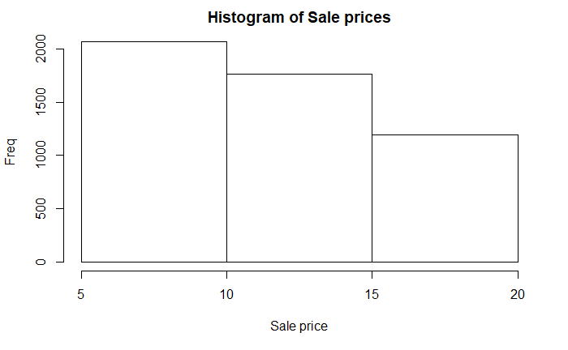

```r
  hist(sales$price,breaks=4,xlab='Sale price', ylab='Freq',main='Histogram of Sale prices')
```

Since the character of food price of act in discrete behavior the break point of 4 seem to be the best fit. The range of 5 seems to be reasonable because the price of food consist of number 5.5, 6.95, 7.95, 8.95, 12.95, 14.95, 17.95 and 18.95. The data doesn’t look like a bell curve but it is right-skewed. It looks like there is no outliner or any missing value. The item price ranked between $5 and $10 are sold most frequently.

### Explore the Histogram of Sale of Approximate Profit Per Unit

Second, let’s look into the distribution of profit per unit

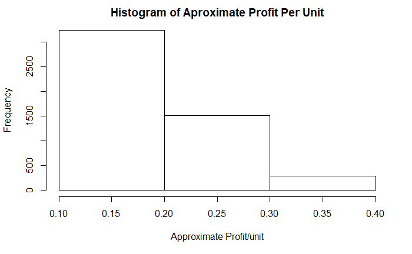

```r
hist(sales$approxProfit, breaks=4, xlab="Approximate Profit/unit", ylab='Frequency', main = 'Histogram of Aproximate Profit Per Unit')
```

### Explore the distribution of Vegan Dish

This will tell us how many vegan dish are sold compared to non-vegan dish.

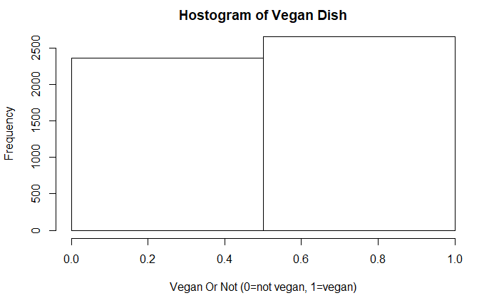

```r
h <-hist(sales$vegan, breaks = 2, xlab = 'Vegan Or Not (0=not vegan, 1=vegan)', main='Hostogram of Vegan Dish')
```

As we can see from the result, the distribution is fall in to 1 more frequently than 0. We’ve discovered that although there are a few vegan dishes in the menu, customers ordered them more than non-vegan dish.

## Using log transformation to reduce skewness of a distribution

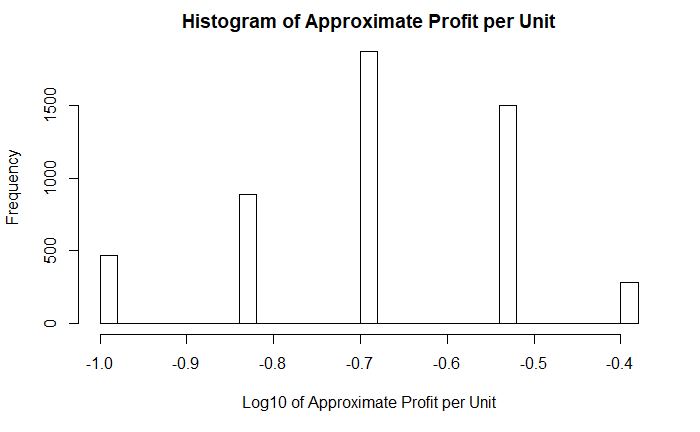

```r
hist(log10(sales$approxProfit),breaks=30, xlab='Log10 of Approximate Profit per Unit', main='Histogram of Approximate Profit per Unit')
```

### Looking at the sales of vegan dish in time series

By total the amount sold of vegan dish in each day (price*quantity*vegan(1 for vegan 0 for the others))

```r
veganSalesByDate <- aggregate((sales[,3]*sales[,4]*sales[,6]),by=list(sales$date),FUN=sum)
veganSalesByDate <- cbind(seq(1,31),veganSalesByDate[,c(1,2)])
names(veganSalesByDate) <- c('day','date','totalVeganSale')
veganSalesByDate
```

| day | date | totalVeganSale |
| --- | --- | --- |
| 1 | 8/01/2019 | 1301.65 |
| 2 | 8/02/2019 | 1295.85 |
| 3 | 8/03/2019 | 1385.60 |
| 4 | 8/04/2019 | 1289.95 |
| 5 | 8/05/2019 | 1430.40 |
| 6 | 8/06/2019 | 1603.55 |
| 7 | 8/07/2019 | 1681.15 |
| 8 | 8/08/2019 | 1389.25 |
| 9 | 8/09/2019 | 1311.90 |
| 10 | 8/10/2019 | 1334.80 |

[output cut: 21 more lines]

```r
plot(veganSalesByDate$day, veganSalesByDate$totalVeganSale, xlab="days", ylab="dollars$",main="Amount of Vegan Dish Sold Each Day")
myline <- lm(veganSalesByDate$totalVeganSale ~ veganSalesByDate$day)
myline
```

```
Call:
lm(formula = veganSalesByDate$totalVeganSale ~ veganSalesByDate$day)

Coefficients:
         (Intercept)  veganSalesByDate$day
            1422.334                -4.593
```

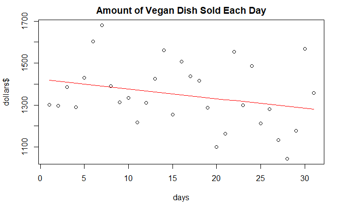

```r
points(veganSalesByDate$day, myline$coefficients[1]+myline$coefficients[2]*veganSalesByDate$day, type ="l",col="red")
```

From the scatter plot, there is no relationship between time and amount vegan dish sold yet. We may have to look in a larger time frame i.e. at least 6 month in order to predict the future trend of vegan dishes.Therefore, the regression model is not be accuracy and doesn’t reflect any relationship between these two.

### Now, Let’s look at the relationship between profit and vegan dish sold

First, we calculate the profit for each day. Then plot it with amount of vegan dish sold and apply regression model.

```r
totalProfitByDate <- aggregate((sales[,3]*sales[,4]*sales[,5]), by=list(sales$date),FUN=sum)
names(totalProfitByDate) <- c('date', 'totalProfit')
totalProfitByDate
```

| date | totalProfit |
| --- | --- |
| 8/01/2019 | 593.5400 |
| 8/02/2019 | 523.9300 |
| 8/03/2019 | 553.4200 |
| 8/04/2019 | 503.2650 |
| 8/05/2019 | 555.2700 |
| 8/06/2019 | 659.5900 |
| 8/07/2019 | 607.2050 |
| 8/08/2019 | 535.0250 |
| 8/09/2019 | 573.6575 |
| 8/10/2019 | 512.9075 |

[output cut: 21 more lines]

```r
NA
```

```r
plot(veganSalesByDate$totalVeganSale, totalProfitByDate$totalProfit, xlab='Vegan Dish Sold ($)', ylab="profit ($)", main="Vegan Dish Sold VS Profit earn (Each Day)")
myline2 <- lm(totalProfitByDate$totalProfit ~ veganSalesByDate$totalVeganSale)
myline2
```

```
Call:
lm(formula = totalProfitByDate$totalProfit ~ veganSalesByDate$totalVeganSale)

Coefficients:
                    (Intercept)  veganSalesByDate$totalVeganSale
                       217.3385                           0.2454
```

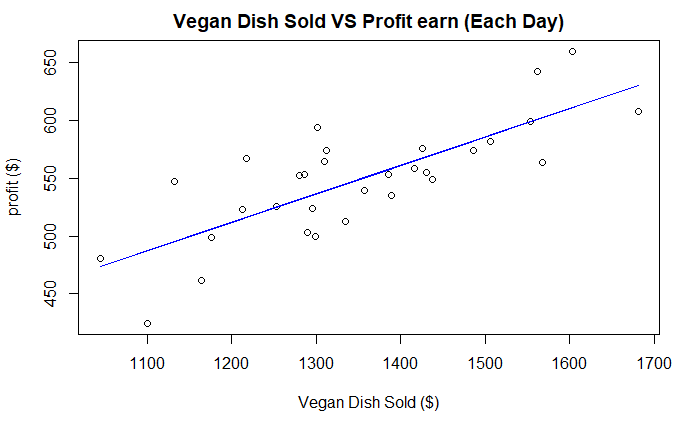

```r
points(veganSalesByDate$totalVeganSale, myline2$coefficients[1]+myline2$coefficients[2]*veganSalesByDate$totalVeganSale, type ='l', col='blue')
```

From the result, the regression line reflects the high relationship between these two variables. The more vegan dish sold the more profit earn.

The linear model is suitable for this data set. It indicated the relationship between profit and vegan dish sold. In my opinion, linear model will be able to predict future trend of vegan customers visiting the restaurant if at least six consecutive months of sales data are used.